# Estudio variabilidad estructural proteica

30/01/2016

## Conjuntos de proteinas

### Conjunto teorico

130 mutantes de 1mld (313 sitios) simuladas con el modelo mutacional LFENM con ANM *R0* = 12 y *Fmax* = 2 (solo para LFENM). Para determinar que sitios mutar, se alineo 1mld con cada una de las proteinas del conjunto, se obtuvieron los indices de los sitios alineados pero mutados y se simularon 10 mutantes por cada par de proteinas, obteniendose un total de 130 mutantes. Luego, para el analisis, se tomaron como alineados los sitios alineados de 1mld para cada par de proteinas.

### Conjunto experimental

13 proteinas de la familia de ldh. Las proteinas tienen un promedio de identidad secuencial de 27%. El core del alineamiento de la familia es de 266 sitios.

La caracterizacion del conjunto experimental se muestra a continuacion:

```
##    pdbid nsites naligned identity       MSD
## 1   2cmd    312      310 58.70968 0.8104368
## 2  1ldna    316      287 23.69338 5.1362570
## 3   1llc    320      289 26.98962 5.3394616
## 4  1llda    313      287 22.99652 6.6871513
## 5  9ldba    331      287 21.95122 4.8435659
## 6   1ldm    329      287 22.99652 4.6003393
## 7   5ldh    333      288 20.13889 8.0122459
## 8   2ldx    331      288 22.56944 5.2154186
## 9  1hlpa    303      286 27.27273 6.1342656
## 10 4mdha    333      302 24.50331 5.5008366
## 11 1bdma    317      289 20.76125 6.8175480
## 12 1ceqa    304      280 25.71429 5.9150795
## 13  1a5z    312      289 28.02768 6.0612471
```

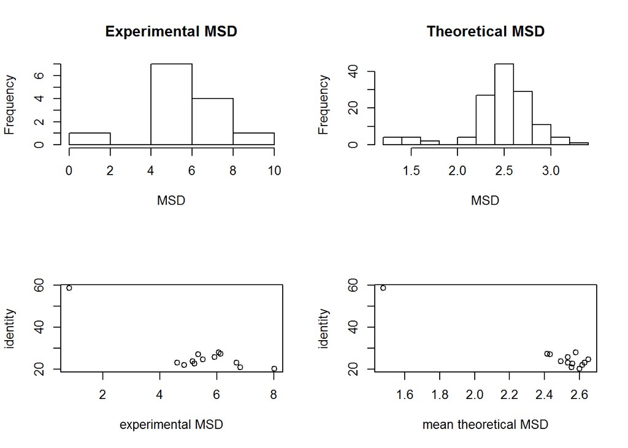

## Comparaciones

### RHO y AUC

Las distribuciones de *auc* y *rho* para cada conjunto se muestran a continuacion (azul= teorico, rojo = experimental)

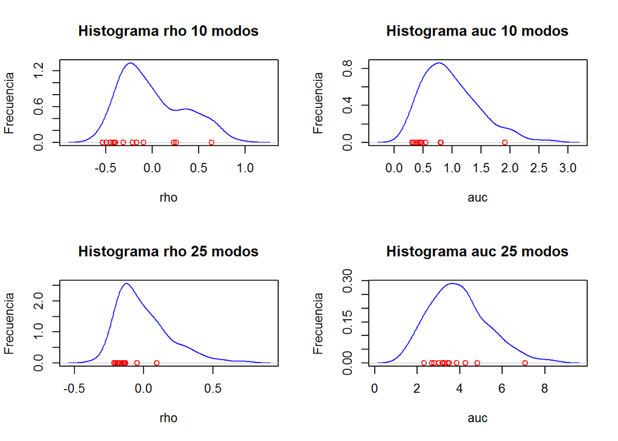

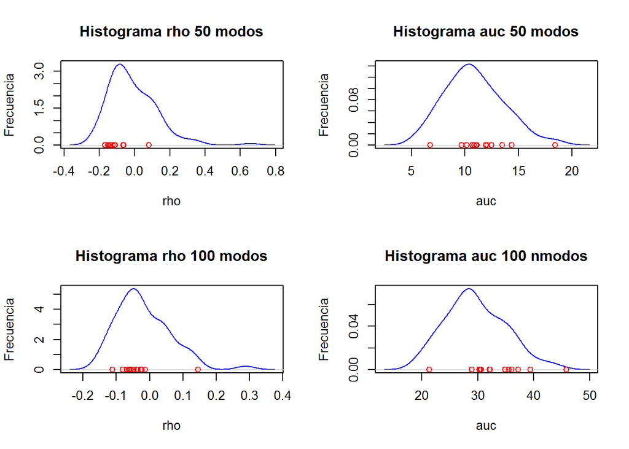

## Pn y Qn

Las distribuciones de *Pn* y *Qn* de los conjuntos son las siguientes:

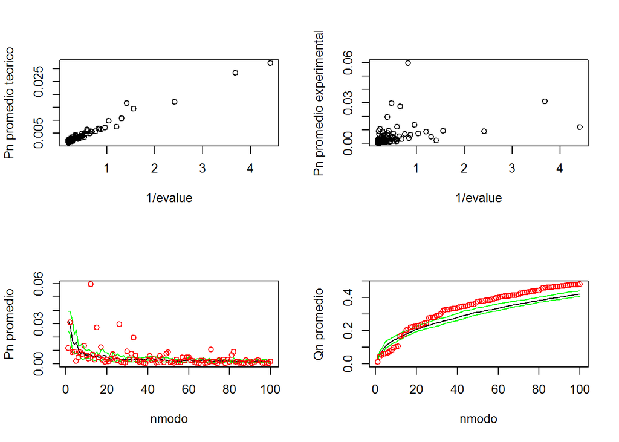

Negro: Teorico Rojo: Experimental Verdes: Cuartiles 0.05 y 0.95 de 10 grupos de 13 mutantes teoricas.